# TGFb + TNF Family Interaction Specificity

EYW

2026-09-22

```r
library(tidyverse)
library(patchwork)
library(viridisLite)
library(ggrepel)
library(RColorBrewer)
library(scales)
library(data.table)
knitr::opts_chunk$set(echo = TRUE)
```

```r
source("../../functions/r_custom/plotting_fxns.R")
theme_set(theme_Publication())

tab10_colors <- c("#1f77b4", "#ff7f0e", "#2ca02c", "#d62728", "#9467bd",
                  "#8c564b", "#e377c2", "#7f7f7f", "#bcbd22", "#17becf")

interaction_palette <- c("#808080","#D95F02","#E7298A","#1B9E77FF")
names(interaction_palette) <- c("none","buffering","synergy negative","synergy positive")

# classes we test for uniqueness
CLASSES <- c("synergy positive","synergy negative","buffering")

out_dir <- "../../analysis_outs/tgfb_tnf"
dir.create(out_dir, showWarnings = FALSE, recursive = TRUE)
```

# Goal

Assess how unique the positive synergy genes of the **TGFB1 x TNF-family** interactions are relative to other TGFB1 interactions and other TNF-family interactions.

# Import

```r
interScored <- data.table::fread(
    "../../analysis_outs/glmGamPoi/interactions_scored_v3_glmGamPoi_0.05filter.csv",
    select = c("name","interaction","lfc_condition","adj_pval_condition",
               "lfc_ligand1","lfc_ligand2","lfc_interaction","adj_pval_interaction",
               "interaction_class")
  ) %>%
  as_tibble() %>%
  mutate(interaction_class = case_when(interaction_class == "additive over saturation" ~ "none",
                                       interaction_class == "buffering complete" ~ "buffering",
                                       is.na(interaction_class) | interaction_class == "" ~ "none",
                                       TRUE ~ interaction_class)) %>%
  mutate(interaction_class = factor(interaction_class,
                                    levels = c("none","buffering","synergy negative","synergy positive"))) %>%
  mutate(lfc_expected = lfc_ligand1 + lfc_ligand2)

# inter-replicate correlations
conditionLfcRep <- readr::read_csv("../../analysis_outs/replicate_corr/replicate_correlation_singleLfc_0.2filter.csv")
interLfcRep <- readr::read_csv("../../analysis_outs/replicate_corr/replicate_correlation_interactionLfc_0.2filter.csv")
singleLfc <- readr::read_csv("../../analysis_outs/glmGamPoi/glmGamPoi_single_term/glmGamPoi_singleTerm_lfc_0.05filter.csv")
```

# Filter and annotate data

Same QC filters as `01`: consistent single-ligand conditions, drop poorly reproducible interaction terms, drop round-2 TGFB1 (inactive — recombinant TGFB1 was only added to round-1 wells), and keep genes that are significant in the condition model (or buffering).

```r
# define consistent ligands by pearson correlation of LFCs
consistentLigands <- conditionLfcRep %>%
  filter(pearson_corr > 0.5) %>%
  pull(condition)

inconsistentInteractions <- interLfcRep %>%
  filter(pearson_corr <= 0.25) %>%
  pull(interaction)

interScoredSig <- interScored %>%
  filter(interaction %in% consistentLigands) %>%
  filter(!interaction %in% inconsistentInteractions) %>%
  # remove _TGFB1 ligands as it is not active
  filter(!grepl("_TGFB1", interaction)) %>%
  # remove genes that are not significant
  filter(adj_pval_condition < 0.1 | interaction_class == "buffering")

# conditions with an appreciable single-term DEG response
combinations_with_effects <- singleLfc %>%
  filter(adj_pval < 0.1) %>%
  count(condition) %>%
  filter(n > 50) %>%
  pull(condition)
```

## Family assignment

TGFb side is **TGFB1 in round 1 only**. TNFSF9 / TNFSF14 are dropped as non-performing, consistent with `01` and `interaction_focused_viz.Rmd`.

```r
TNF_FAMILY <- c("TNF","TNFSF4","TNFSF15","TNFSF18")

interAnnot <- interScoredSig %>%
  # TGFB3 / MSTN are not treated as TGFb here; TNFSF9/14 are non-performing
  filter(!grepl("TGFB3|MSTN|TNFSF9|TNFSF14", interaction)) %>%
  separate(interaction, into = c("lig1","lig2"), sep = "_", remove = FALSE) %>%
  mutate(has_tgfb = lig1 == "TGFB1",
         has_tnf = lig1 %in% TNF_FAMILY | lig2 %in% TNF_FAMILY,
         has_linker = lig1 == "linker" | lig2 == "linker",
         is_homotypic = lig1 == lig2) %>%
  mutate(family_group = case_when(
    has_linker | is_homotypic ~ "excluded",
    has_tgfb & has_tnf ~ "TGFb x TNF",
    has_tgfb & !has_tnf ~ "TGFb other",
    has_tnf & !has_tgfb ~ "TNF other",
    TRUE ~ "other"
  )) %>%
  mutate(family_group = factor(family_group,
                               levels = c("TGFb x TNF","TGFb other","TNF other","other","excluded")))

# condition sets
focalConditions <- interAnnot %>%
  filter(family_group == "TGFb x TNF") %>%
  pull(interaction) %>% unique() %>% sort()

tgfbOtherConditions <- interAnnot %>%
  filter(family_group == "TGFb other") %>%
  pull(interaction) %>% unique() %>% sort()

tnfOtherConditions <- interAnnot %>%
  filter(family_group == "TNF other") %>%
  pull(interaction) %>% unique() %>% sort()

backgroundConditions <- union(tgfbOtherConditions, tnfOtherConditions)

focalConditions
```

```
## [1] "TGFB1_TNF"     "TGFB1_TNFSF15" "TGFB1_TNFSF18" "TGFB1_TNFSF4"
```

```r
length(tgfbOtherConditions); length(tnfOtherConditions)
```

```
## [1] 27
```

```
## [1] 58
```

```r
# focal conditions that also clear the >50 DEG bar (these get plotted)
focalPlotConditions <- intersect(focalConditions, combinations_with_effects)
focalPlotConditions
```

```
## [1] "TGFB1_TNF"     "TGFB1_TNFSF15" "TGFB1_TNFSF18" "TGFB1_TNFSF4"
```

```r
setdiff(focalConditions, combinations_with_effects)
```

```
## character(0)
```

# Uniqueness of interaction hits

A gene counts as **unique** to a condition for a given interaction class if it carries that class in the condition and does *not* carry that class in any of the background conditions.

```r
# long table of class hits, one row per gene x condition x class
classHits <- interAnnot %>%
  filter(interaction_class %in% CLASSES) %>%
  distinct(interaction, family_group, interaction_class, name)

#' Fraction of each class's hit genes that are unique to a focal condition.
#'
#' @param hits long table with columns interaction, interaction_class, name
#' @param focal character vector of conditions to score
#' @param background character vector of conditions forming the comparison set.
#'   The focal condition itself is always removed from its own background.
uniqueness_table <- function(hits, focal, background) {
  map_dfr(focal, function(cond) {
    bg <- setdiff(background, cond)
    map_dfr(CLASSES, function(cls) {
      focal_genes <- hits %>%
        filter(interaction == cond, interaction_class == cls) %>%
        pull(name) %>% unique()
      bg_genes <- hits %>%
        filter(interaction %in% bg, interaction_class == cls) %>%
        pull(name) %>% unique()
      n_total <- length(focal_genes)
      n_unique <- length(setdiff(focal_genes, bg_genes))
      tibble(interaction = cond,
             interaction_class = cls,
             n_total = n_total,
             n_unique = n_unique,
             pct_unique = if (n_total > 0) n_unique / n_total * 100 else NA_real_)
    })
  }) %>%
    mutate(interaction_class = factor(interaction_class, levels = CLASSES))
}
```

## Primary: TGFb x TNF vs other TGFb / TNF interactions

```r
uniqFocal <- uniqueness_table(classHits, focalPlotConditions, backgroundConditions)
uniqFocal
```

```
## # A tibble: 12 × 5
##    interaction   interaction_class n_total n_unique pct_unique
##    <chr>         <fct>               <int>    <int>      <dbl>
##  1 TGFB1_TNF     synergy positive       90       34      37.8
##  2 TGFB1_TNF     synergy negative       19        9      47.4
##  3 TGFB1_TNF     buffering             101       13      12.9
##  4 TGFB1_TNFSF15 synergy positive       65       25      38.5
##  5 TGFB1_TNFSF15 synergy negative       16        5      31.2
##  6 TGFB1_TNFSF15 buffering              39        3       7.69
##  7 TGFB1_TNFSF18 synergy positive      104       51      49.0
##  8 TGFB1_TNFSF18 synergy negative       32       20      62.5
##  9 TGFB1_TNFSF18 buffering             404       66      16.3
## 10 TGFB1_TNFSF4  synergy positive       26       10      38.5
## 11 TGFB1_TNFSF4  synergy negative       19        5      26.3
## 12 TGFB1_TNFSF4  buffering              54        2       3.70
```

```r
stopifnot(all(uniqFocal$n_unique <= uniqFocal$n_total))

# sanity: if a condition is in its own background it can have no unique genes
uniqueness_table(classHits, focalPlotConditions[1],
                 union(backgroundConditions, focalPlotConditions[1])) %>%
  summarise(all_zero = all(n_unique == 0, na.rm = TRUE))
```

```
## # A tibble: 1 × 1
##   all_zero
##   <lgl>
## 1 FALSE
```

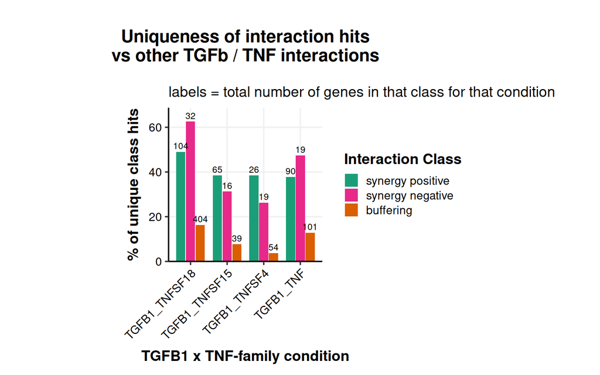

```r
barOrder <- uniqFocal %>%
  filter(interaction_class == "synergy positive") %>%
  arrange(desc(pct_unique)) %>%
  pull(interaction)

uniqFocal %>%
  filter(!is.na(pct_unique)) %>%
  mutate(interaction = factor(interaction, levels = barOrder)) %>%
  ggplot(aes(x = interaction, y = pct_unique, fill = interaction_class)) +
    geom_col(position = position_dodge(width = 0.8), width = 0.75) +
    geom_text(aes(label = n_total), position = position_dodge(width = 0.8),
              vjust = -0.4, size = 3) +
    scale_fill_manual(values = interaction_palette, breaks = CLASSES) +
    scale_y_continuous(expand = expansion(mult = c(0, 0.1))) +
    labs(x = "TGFB1 x TNF-family condition",
         y = "% of unique class hits",
         fill = "Interaction Class",
         title = "Uniqueness of interaction hits\nvs other TGFb / TNF interactions",
         subtitle = "labels = total number of genes in that class for that condition") +
    theme(aspect.ratio = 1,
          axis.text.x = element_text(angle = 45, hjust = 1))
```

```r
ggsave("../../analysis_outs/plots/tgfb_tnf_unique_class_percent_barplot.pdf")
```

## Family-level: the TGFB1 x TNF-family set as a whole

```r
family_uniqueness <- map_dfr(CLASSES, function(cls) {
  focal_genes <- classHits %>%
    filter(interaction %in% focalPlotConditions, interaction_class == cls) %>%
    pull(name) %>% unique()
  bg_genes <- classHits %>%
    filter(interaction %in% backgroundConditions, interaction_class == cls) %>%
    pull(name) %>% unique()
  tibble(interaction_class = cls,
         n_total = length(focal_genes),
         n_unique = length(setdiff(focal_genes, bg_genes)),
         pct_unique = length(setdiff(focal_genes, bg_genes)) / length(focal_genes) * 100)
}) %>%
  mutate(interaction_class = factor(interaction_class, levels = CLASSES))

family_uniqueness
```

```
## # A tibble: 3 × 4
##   interaction_class n_total n_unique pct_unique
##   <fct>               <int>    <int>      <dbl>
## 1 synergy positive      174       79       45.4
## 2 synergy negative       71       35       49.3
## 3 buffering             456       75       16.4
```

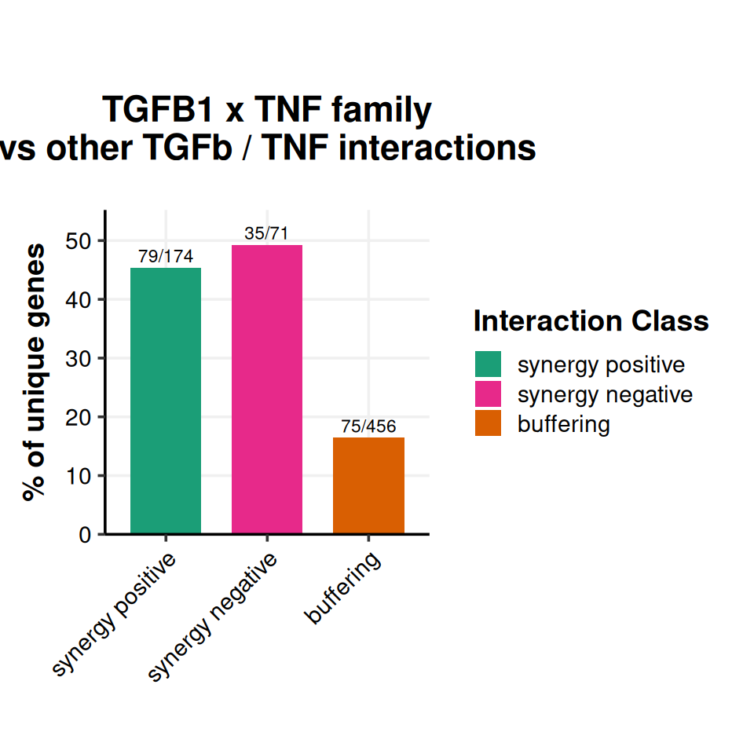

```r
family_uniqueness %>%
  ggplot(aes(x = interaction_class, y = pct_unique, fill = interaction_class)) +
    geom_col(width = 0.7) +
    geom_text(aes(label = paste0(n_unique, "/", n_total)), vjust = -0.4, size = 3) +
    scale_fill_manual(values = interaction_palette, breaks = CLASSES) +
    scale_y_continuous(expand = expansion(mult = c(0, 0.12))) +
    labs(x = NULL, y = "% of unique genes",
         fill = "Interaction Class",
         title = "TGFB1 x TNF family\nvs other TGFb / TNF interactions") +
    theme(aspect.ratio = 1,
          axis.text.x = element_text(angle = 45, hjust = 1))
```

```r
ggsave("../../analysis_outs/plots/tgfb_tnf_family_unique_class_percent_barplot.pdf")
# export tables
readr::write_csv(uniqFocal, file.path(out_dir, "uniqueness_by_condition_class.csv"))

uniqueGenes <- map_dfr(focalPlotConditions, function(cond) {
  bg <- setdiff(backgroundConditions, cond)
  map_dfr(CLASSES, function(cls) {
    focal_genes <- classHits %>% filter(interaction == cond, interaction_class == cls) %>%
      pull(name) %>% unique()
    bg_genes <- classHits %>% filter(interaction %in% bg, interaction_class == cls) %>%
      pull(name) %>% unique()
    tibble(interaction = cond, interaction_class = cls,
           name = setdiff(focal_genes, bg_genes))
  })
})

readr::write_csv(uniqueGenes, file.path(out_dir, "unique_genes_tgfb_tnf.csv"))
uniqueGenes %>% count(interaction, interaction_class)
```

```
## # A tibble: 12 × 3
##    interaction   interaction_class     n
##    <chr>         <chr>             <int>
##  1 TGFB1_TNF     buffering            13
##  2 TGFB1_TNF     synergy negative      9
##  3 TGFB1_TNF     synergy positive     34
##  4 TGFB1_TNFSF15 buffering             3
##  5 TGFB1_TNFSF15 synergy negative      5
##  6 TGFB1_TNFSF15 synergy positive     25
##  7 TGFB1_TNFSF18 buffering            66
##  8 TGFB1_TNFSF18 synergy negative     20
##  9 TGFB1_TNFSF18 synergy positive     51
## 10 TGFB1_TNFSF4  buffering             2
## 11 TGFB1_TNFSF4  synergy negative      5
## 12 TGFB1_TNFSF4  synergy positive     10
```

## Per-gene examples

Top unique positive-synergy genes of `TGFB1_TNF` by interaction significance, shown across all TGFb / TNF conditions. Single-ligand arms are placed on the diagonal (as in `01`) by setting their expected LFC to the observed LFC.

```r
exampleGenes <- interAnnot %>%
  filter(interaction == "TGFB1_TNF", interaction_class == "synergy positive") %>%
  semi_join(uniqueGenes %>% filter(interaction == "TGFB1_TNF",
                                   interaction_class == "synergy positive"),
            by = "name") %>%
  slice_min(adj_pval_interaction, n = 4) %>%
  pull(name)

exampleGenes
```

```
## [1] "Ahnak" "Gata3" "Spn"   "N4bp1"
```

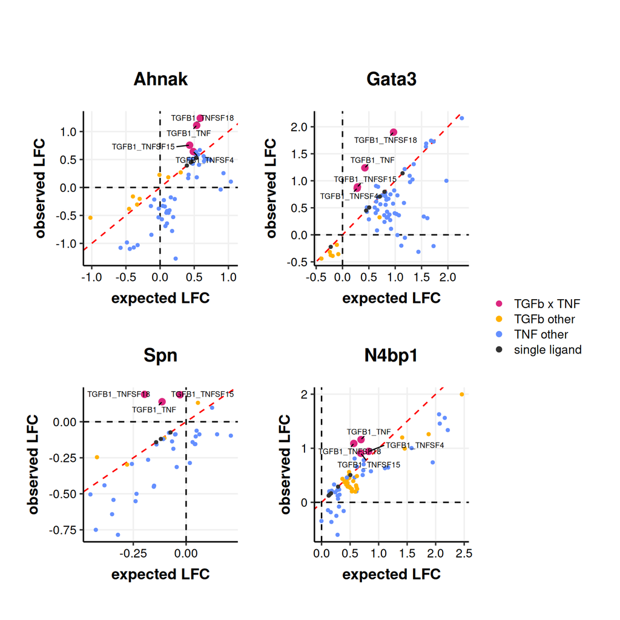

```r
# single-ligand arms for the TGFb / TNF ligands, forced onto the diagonal
singleArms <- interScoredSig %>%
  filter(grepl("^linker_(TGFB1|TNF|TNFSF4|TNFSF15|TNFSF18)$|^(TGFB1|TNF)_linker$", interaction)) %>%
  mutate(family_group = "single ligand",
         lfc_expected = lfc_condition)

exampleData <- interAnnot %>%
  select(name, interaction, lfc_expected, lfc_condition, family_group, interaction_class) %>%
  mutate(family_group = as.character(family_group)) %>%
  bind_rows(singleArms %>% select(name, interaction, lfc_expected, lfc_condition,
                                  family_group, interaction_class)) %>%
  mutate(family_group = factor(family_group,
                               levels = c("TGFb x TNF","TGFb other","TNF other","single ligand")))

group_colors <- c("TGFb x TNF" = "#DC267F",
                  "TGFb other" = "#FFB000",
                  "TNF other"  = "#648FFF",
                  "single ligand" = "grey20")

plot_gene <- function(g) {
  d <- exampleData %>% filter(name == g, !is.na(family_group))
  ggplot(d, aes(x = lfc_expected, y = lfc_condition)) +
    geom_abline(intercept = 0, slope = 1, color = "red", linetype = "dashed") +
    geom_hline(yintercept = 0, linetype = "dashed") +
    geom_vline(xintercept = 0, linetype = "dashed") +
    geom_point(aes(color = family_group, size = family_group == "TGFb x TNF")) +
    geom_text_repel(data = d %>% filter(family_group == "TGFb x TNF"),
                    aes(label = interaction), size = 2.5,
                    max.overlaps = 100, min.segment.length = 0) +
    scale_color_manual(values = group_colors) +
    scale_size_manual(values = c(`FALSE` = 1, `TRUE` = 2.4), guide = "none") +
    xlab("expected LFC") +
    ylab("observed LFC") +
    labs(color = NULL) +
    ggtitle(g) +
    theme(aspect.ratio = 1)
}

wrap_plots(map(exampleGenes, plot_gene), ncol = 2) + plot_layout(guides = "collect")
```

```r
ggsave("../../analysis_outs/plots/tgfb_tnf_unique_synergy_gene_examples.pdf")
```